# Metric data: regression and relatives

Peter Ralph

12 February 2018 – Advanced Biological Statistics

# Overview

## Summary

Last Thursday, we looked at:

1. Using non-Normal noise distributions (e.g., Cauchy) to make models *robust* to outliers and more generally model overdispersed data.
2. Interrogating hyperparameters to learn what we want (e.g., percent variation explained).

## Today

0. Finish up robust ANOVA.
1. Problem #1: “too much” noise (i.e., non-Normal noise).
2. Problem #2: too many variables.

# Robust regression

## Some data

Relative axon growth for neurons after $x$ hours:

```r
truth <- list(b0=1.0, b1=3.0, sigma=0.5)
n <- 200
x <- rnorm(n, mean=0, sd=3)
y <- ( truth$b0 + truth$b1 * x
        + rcauchy(n, location=0,
                  scale=truth$sigma) )
```

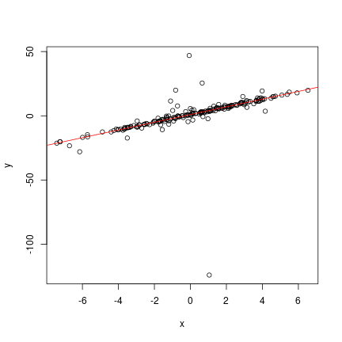

Standard linear regression

```r
system.time( slr2 <- lm(y ~ x) )
```

```
##    user  system elapsed
##   0.005   0.000   0.004
```

```r
summary(slr2)
```

```
##
## Call:
## lm(formula = y ~ x)
##
## Residuals:
##      Min       1Q   Median       3Q      Max
## -127.829   -0.307    0.234    0.691   46.293
##
## Coefficients:
##             Estimate Std. Error t value Pr(>|t|)
## (Intercept)   0.8164     0.7202   1.133    0.258
## x             2.9323     0.2582  11.356   <2e-16 ***
## ---
## Signif. codes:  0 '***' 0.001 '**' 0.01 '*' 0.05 '.' 0.1 ' ' 1
##
## Residual standard error: 10.18 on 198 degrees of freedom
## Multiple R-squared:  0.3944, Adjusted R-squared:  0.3913
## F-statistic:   129 on 1 and 198 DF,  p-value: < 2.2e-16
```

with Stan

```r
srr_block <- "
data {
    int N;
    vector[N] x;
    vector[N] y;
}
parameters {
    real b0;
    real b1;
    real<lower=0> sigma;
}
model {
    y ~ cauchy(b0 + b1*x, sigma);
}"
system.time( stanrr <- stan(model_code=srr_block,
                            data=list(N=length(x), x=x, y=y), iter=1e3) )
```

```
##    user  system elapsed
##  36.170   0.947  42.192
```

```r
rstan::summary(stanrr)
```

```
## $summary
##               mean      se_mean         sd         2.5%          25%
## b0       1.0492653 0.0011858160 0.04901458    0.9556078    1.0153481
## b1       3.0175214 0.0003716323 0.01579547    2.9876462    3.0068720
## sigma    0.4887785 0.0011772173 0.05008859    0.3999234    0.4549012
## lp__  -143.9498680 0.0440483247 1.29259423 -147.3354709 -144.5436828
##                50%         75%       97.5%     n_eff      Rhat
## b0       1.0491830    1.081127    1.144147 1708.5037 0.9996744
## b1       3.0172806    3.027901    3.048448 1806.5022 0.9985911
## sigma    0.4863373    0.519511    0.598097 1810.3575 1.0001622
## lp__  -143.6147451 -143.008105 -142.518558  861.1239 1.0039008
##
## $c_summary
## , , chains = chain:1
##
##          stats
## parameter         mean         sd         2.5%          25%          50%
##     b0       1.0516070 0.04808494    0.9561784    1.0172640    1.0535676
##     b1       3.0168313 0.01636800    2.9872796    3.0052616    3.0159255
##     sigma    0.4872553 0.04932650    0.3966417    0.4543649    0.4835046
##     lp__  -143.9923917 1.28438229 -147.4284683 -144.6003711 -143.6344760
##          stats
## parameter          75%       97.5%
##     b0       1.0846034    1.142480
##     b1       3.0277263    3.050457
##     sigma    0.5192919    0.591551
##     lp__  -143.0595455 -142.523462
##
## , , chains = chain:2
##
##          stats
## parameter         mean         sd         2.5%          25%          50%
##     b0       1.0467663 0.04860953    0.9543881    1.0131220    1.0468940
##     b1       3.0178001 0.01599980    2.9886282    3.0064272    3.0173143
##     sigma    0.4910389 0.05262914    0.4006050    0.4540697    0.4899721
##     lp__  -143.9991601 1.36601484 -147.4543730 -144.5897508 -143.6740284
##          stats
## parameter          75%        97.5%
##     b0       1.0773398    1.1438271
##     b1       3.0283606    3.0478673
```

[output cut: 17 more lines]

```
##
## , , chains = chain:4
##
##          stats
## parameter         mean         sd         2.5%          25%         50%
##     b0       1.0489423 0.04922303    0.9552911    1.0157737    1.048428
##     b1       3.0173506 0.01593153    2.9864034    3.0071933    3.017419
##     sigma    0.4888364 0.04837375    0.4060966    0.4562453    0.484854
##     lp__  -143.8798493 1.28859894 -147.1772748 -144.5032436 -143.479043
##          stats
## parameter          75%        97.5%
##     b0       1.0795552    1.1438732
##     b1       3.0276787    3.0476952
##     sigma    0.5157548    0.5962235
##     lp__  -142.9418798 -142.5069584
```

## Compare the results.

Make a table and/or a graph of estimates and confidence intervals obtained by (a) ordinary linear regression and (b) robust regression as we have done here.

# Problem #2: too many variables

## Example data

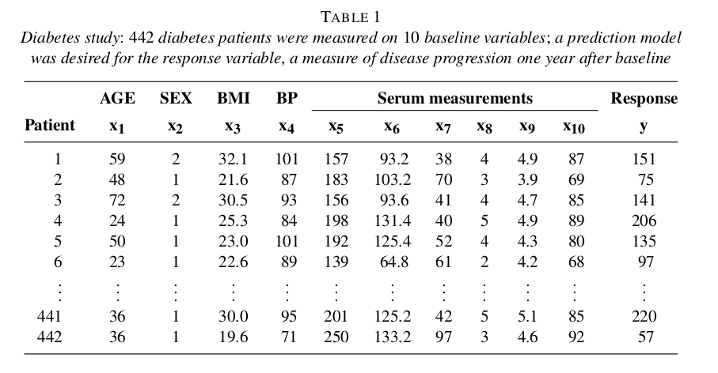

from Efron, Hastie, Johnstone, & Tibshirani

```r
library(lars)
data(diabetes)
class(diabetes$x2) <- "matrix"
```

```
diabetes                 package:lars                  R Documentation

Blood and other measurements in diabetics

Description:

     The ‘diabetes’ data frame has 442 rows and 3 columns. These are
     the data used in the Efron et al "Least Angle Regression" paper.

Format:

     This data frame contains the following columns:

     x a matrix with 10 columns

     y a numeric vector

     x2 a matrix with 64 columns
```

The dataset has

- 442 diabetes patients
- 10 main variables: age, gender, body mass index, average blood pressure (map), and six blood serum measurements (tc, ldl, hdl, tch, ltg, glu)
- 45 interactions, e.g. `age:ldl`
- 9 quadratic effects, e.g. `age^2`
- measure of disease progression taken one year later, `y`

## Crossvalidation plan

1. Put aside 20% of the data for *testing*.
2. Refit the model.
3. Predict the test data; compute
   $$\begin{aligned}
   S = \sqrt{\frac{1}{M} \sum_{k=1}^M (\hat y_i - y_i)^2}
   \end{aligned}$$
4. Repeat for the other four 20%s.
5. Compare.

## Crossvalidation

First let’s split the data into testing and training just once:

```r
test_indices <- (rbinom(length(diabetes$y), size=1, prob=0.2) == 1)
test_d <- cbind(data.frame(y=diabetes$y[test_indices]),
                diabetes$x2[test_indices,])
training_d <- cbind(data.frame(y=diabetes$y[!test_indices]),
                diabetes$x2[!test_indices,])
```

## Ordinary linear regression

```r
ols <- lm(y ~ ., data=training_d)
summary(ols)
```

```
##
## Call:
## lm(formula = y ~ ., data = training_d)
##
## Residuals:
##      Min       1Q   Median       3Q      Max
## -116.452  -31.222   -2.942   30.048  115.597
##
## Coefficients:
##               Estimate Std. Error t value Pr(>|t|)
## (Intercept)    150.404      2.925  51.421  < 2e-16 ***
## age            131.031     77.503   1.691 0.092046 .
## sex           -286.088     77.795  -3.677 0.000284 ***
## bmi            587.855     99.149   5.929 9.22e-09 ***
## map            323.091     84.736   3.813 0.000170 ***
## tc           16796.166  63143.128   0.266 0.790440
## ldl         -15061.254  55494.787  -0.271 0.786290
## hdl          -6254.463  23596.136  -0.265 0.791162
## tch            330.715    316.398   1.045 0.296835
## ltg          -4856.914  20761.268  -0.234 0.815207
## glu             19.128     79.886   0.239 0.810945
## `age^2`        123.345     78.097   1.579 0.115410
## `bmi^2`        -57.665     91.584  -0.630 0.529454
## `map^2`       -161.860    102.020  -1.587 0.113777
## `tc^2`       11301.512   7685.114   1.471 0.142563
## `ldl^2`       7536.397   5812.171   1.297 0.195848
## `hdl^2`       2298.167   1803.074   1.275 0.203545
## `tch^2`        756.037    717.721   1.053 0.293100
## `ltg^2`       1549.779   1936.210   0.800 0.424167
## `glu^2`         49.718    107.963   0.461 0.645518
## `age:sex`      149.665     89.058   1.681 0.093999 .
## `age:bmi`      -51.026     89.830  -0.568 0.570480
## `age:map`       73.426     88.382   0.831 0.406825
## `age:tc`      -147.148    718.847  -0.205 0.837960
## `age:ldl`     -215.127    576.917  -0.373 0.709521
## `age:hdl`      349.106    337.121   1.036 0.301331
## `age:tch`      450.274    258.548   1.742 0.082718 .
## `age:ltg`       31.703    276.056   0.115 0.908655
## `age:glu`       65.267     92.163   0.708 0.479443
## `sex:bmi`      -14.043     91.191  -0.154 0.877726
```

[output cut: 26 more lines]

```
## `ldl:tch`     1731.892   1615.223   1.072 0.284567
## `ldl:ltg`     8124.594  11369.412   0.715 0.475468
## `ldl:glu`      265.993    594.756   0.447 0.655064
## `hdl:tch`     1076.355   1217.662   0.884 0.377503
## `hdl:ltg`     3597.256   4794.265   0.750 0.453708
## `hdl:glu`      560.737    366.606   1.530 0.127294
## `tch:ltg`      212.466    727.798   0.292 0.770563
## `tch:glu`      596.191    278.394   2.142 0.033119 *
## `ltg:glu`      172.802    328.491   0.526 0.599283
## ---
## Signif. codes:  0 '***' 0.001 '**' 0.01 '*' 0.05 '.' 0.1 ' ' 1
##
## Residual standard error: 51.82 on 272 degrees of freedom
## Multiple R-squared:  0.6421, Adjusted R-squared:  0.5579
## F-statistic: 7.625 on 64 and 272 DF,  p-value: < 2.2e-16
```

```r
ols_pred <- predict(ols, newdata=test_d)
ols_mse <- sqrt(mean((ols_pred - test_d$y)^2))
```

With ordinary linear regression, we got a root-mean-square-prediction-error of 64.602275 (on the *test* data), compared to a root-mean-square-error of 46.5588313 for the *training* data.

This suggests there’s some overfitting going on.

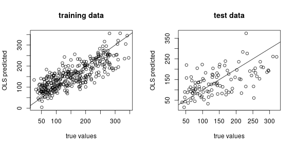

```r
layout(t(1:2))
plot(training_d$y, predict(ols), xlab="true values", ylab="OLS predicted", main="training data")
abline(0,1)
plot(test_d$y, ols_pred, xlab="true values", ylab="OLS predicted", main="test data")
abline(0,1)
```

## A sparsifying prior

We have a lot of predictors: 64 of them. A good guess is that only a few are really useful. So, we can put a *sparsifying* prior on the coefficients, i.e., the $\beta$s in
$$\begin{aligned}
y = \beta_0 + \beta_1 x_1 + \cdots \beta_n x_n + \epsilon
\end{aligned}$$

# Sparseness and scale mixtures

## Encouraging sparseness

Suppose we do regression with a *large* number of predictor variables.

The resulting coefficients are **sparse** if most are zero.

The idea is to “encourage” all the coefficients to be zero, **unless** they *really* want to be nonzero, in which case we let them be whatever they want.

This tends to discourage overfitting.

> The idea is to “encourage” all the coefficients to be zero, **unless** they *really* want to be nonzero, in which case we let them be whatever they want.

To do this, we want a prior which is very peak-ey at zero *but* flat away from zero (“spike-and-slab”).

Compare the Normal

$$\begin{aligned}
X \sim \Normal(0,1)
\end{aligned}$$

to the “exponential scale mixture of Normals”,

$$\begin{aligned}
X &\sim \Normal(0,\sigma) \\
\sigma &\sim \Exp(1) .
\end{aligned}$$

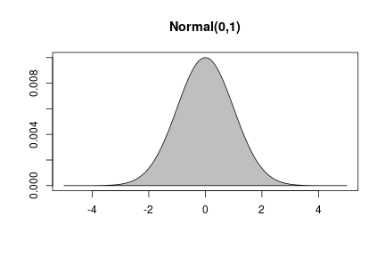

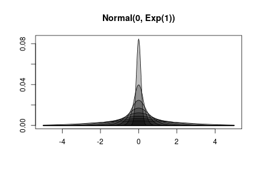

## Why use a scale mixture?

1. Lets the data choose the appropriate scale of variation.
2. Weakly encourages $\sigma$ to be small: so, as much variation as possible is explained by *signal* instead of *noise*.
3. Gets you a prior that is more peaked at zero and flatter otherwise.

## Implementation

Note that

$$\begin{aligned}
\beta &\sim \Normal(0,\sigma) \\
\sigma &\sim \Exp(1) .
\end{aligned}$$

is equivalent to

$$\begin{aligned}
\beta &= \sigma \gamma \\
\gamma &\sim \Normal(0,1) \\
\sigma &\sim \Exp(1) .
\end{aligned}$$

```
parameters {
    real beta;
    real<lower=0> sigma;
}
model {
    beta ~ normal(0, sigma);
}
```

is equivalent to

[output not shown]

The second version **is better** for Stan.

Why is it better?

```
parameters {
    real beta;
    real<lower=0> sigma;
}
model {
    beta ~ normal(0, sigma);
}
```

In the first, the optimal step size *depends on `sigma`*.

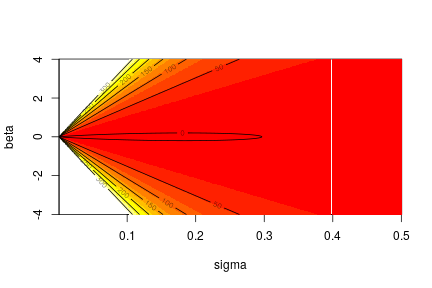

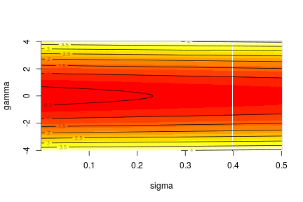

## A strongly sparsifying prior

The “horseshoe”:

$$\begin{aligned}
\beta_j &\sim \Normal(0, \lambda_j) \\
\lambda_j &\sim \Cauchy(0, \tau) \\
\tau &\sim \Unif(0, 1)
\end{aligned}$$

```
parameters {
    vector[p] d_beta;
    vector[p] d_lambda;
    real<lower=0, upper=1> tau;
}
transformed parameters {
    vector[p] beta;
    beta = d_beta .* d_lambda * tau;
}
model {
    d_beta ~ normal(0, 1);
    d_lambda ~ cauchy(0, 1);
    // tau ~ uniform(0, 1); // uniform
}
```

# The Cauchy as a scale mixture

## Inverse square-root gamma scaling

It turns out that if

$$\begin{aligned}
\beta &\sim \Normal(0, 1/\sqrt{\lambda}) \\
\lambda &\sim \Gam(1/2, 1/2)
\end{aligned}$$

then

$$\begin{aligned}
\beta &\sim \Cauchy(0, 1).
\end{aligned}$$

*What black magic is this??*

1. It says so [here](https://betanalpha.github.io/assets/case_studies/fitting_the_cauchy.html).
2. If you like to do integrals, you can check mathematically.
3. Or, you can check with *simulation*.

# Using the horseshoe

## What’s an appropriate noise distribution?

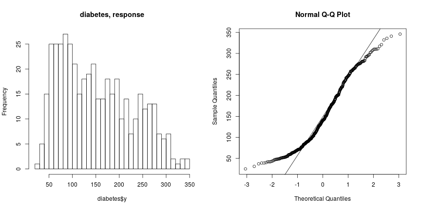

## Aside: quantile-quantile plots

The idea is to plot the *quantiles* of each distribution against each other.

If these are *datasets*, this means just plotting their *sorted values* against each other.

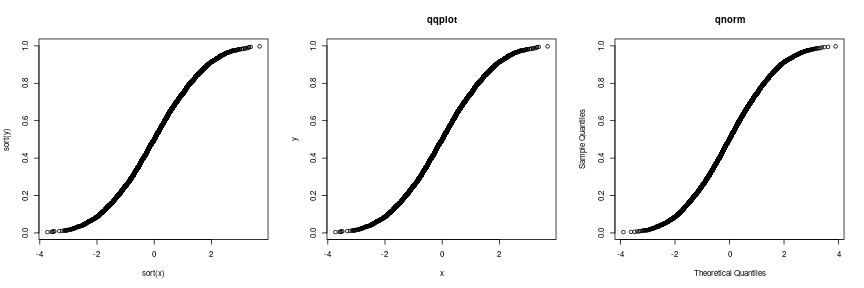

```r
x <- rnorm(1e4)
y <- rbeta(1e4, 2, 2)

layout(t(1:3))
plot(sort(x), sort(y))
qqplot(x, y, main="qqplot")
qqnorm(y, main="qnorm")
```

## Regression with a horseshoe prior

Uses a [reparameterization](https://betanalpha.github.io/assets/case_studies/fitting_the_cauchy.html) of the Cauchy as a scale mixture of normals.

```r
horseshoe_block <- "
data {
    int N;
    int p;
    vector[N] y;
    matrix[N,p] x;
}
parameters {
    real b0;
    vector[p] d_beta;
    vector[p] d_a;
    vector<lower=0>[p] d_b;
    real<lower=0, upper=1> tau;
    real<lower=0> sigma;
}
transformed parameters {
    vector[p] beta;
    vector[N] f;
    beta = d_beta .* d_a .* sqrt(d_b) * tau;
    f = b0 + x * beta;
}
model {
    y ~ normal(f, sigma);
    // HORSESHOE PRIOR:
    d_beta ~ normal(0, 1);
    d_a ~ normal(0, 1);
    d_b ~ inv_gamma(0.5, 0.5);
    // tau ~ uniform(0, 1); // uniform
    // priors on noise distribution:
    sigma ~ normal(0, 10);
}"
```

Note the data have already been normalized, with the exception of $y$:

```r
summary(training_d)
```

```
##        y              age                  sex
##  Min.   : 25.0   Min.   :-0.1072256   Min.   :-0.044642
##  1st Qu.: 88.0   1st Qu.:-0.0345749   1st Qu.:-0.044642
##  Median :142.0   Median : 0.0053831   Median :-0.044642
##  Mean   :154.3   Mean   : 0.0000151   Mean   : 0.000615
##  3rd Qu.:215.0   3rd Qu.: 0.0380759   3rd Qu.: 0.050680
##  Max.   :346.0   Max.   : 0.1107267   Max.   : 0.050680
##       bmi                 map                   tc
##  Min.   :-0.090275   Min.   :-0.1123996   Min.   :-0.126781
##  1st Qu.:-0.032073   1st Qu.:-0.0366565   1st Qu.:-0.033216
##  Median :-0.005128   Median :-0.0056706   Median :-0.000193
##  Mean   : 0.002986   Mean   :-0.0002015   Mean   : 0.001795
##  3rd Qu.: 0.035829   3rd Qu.: 0.0333486   3rd Qu.: 0.032830
##  Max.   : 0.170555   Max.   : 0.1079441   Max.   : 0.153914
##       ldl                 hdl                 tch
##  Min.   :-0.115613   Min.   :-0.102307   Min.   :-0.076395
##  1st Qu.:-0.028558   1st Qu.:-0.032356   1st Qu.:-0.039493
##  Median :-0.002880   Median :-0.006584   Median :-0.002592
##  Mean   : 0.002058   Mean   :-0.002635   Mean   : 0.002334
##  3rd Qu.: 0.034698   3rd Qu.: 0.026550   3rd Qu.: 0.034309
##  Max.   : 0.155887   Max.   : 0.177497   Max.   : 0.155345
##       ltg                  glu                 age^2
##  Min.   :-0.1043648   Min.   :-0.1377672   Min.   :-0.04130
##  1st Qu.:-0.0307512   1st Qu.:-0.0300725   1st Qu.:-0.03651
##  Median : 0.0002715   Median :-0.0010777   Median :-0.01950
##  Mean   : 0.0029586   Mean   : 0.0004587   Mean   :-0.00153
##  3rd Qu.: 0.0336568   3rd Qu.: 0.0279170   3rd Qu.: 0.01646
##  Max.   : 0.1335990   Max.   : 0.1356118   Max.   : 0.18276
##      bmi^2               map^2                tc^2
##  Min.   :-0.032976   Min.   :-0.039369   Min.   :-0.0319463
##  1st Qu.:-0.029542   1st Qu.:-0.034253   1st Qu.:-0.0291980
##  Median :-0.016958   Median :-0.018662   Median :-0.0163678
##  Mean   : 0.001593   Mean   :-0.001993   Mean   : 0.0005684
##  3rd Qu.: 0.015956   3rd Qu.: 0.015789   3rd Qu.: 0.0090080
##  Max.   : 0.391017   Max.   : 0.180473   Max.   : 0.3025598
##      ldl^2                hdl^2               tch^2
##  Min.   :-0.0296059   Min.   :-0.027654   Min.   :-0.0305374
##  1st Qu.:-0.0261629   1st Qu.:-0.025283   1st Qu.:-0.0301802
##  Median :-0.0178284   Median :-0.014861   Median :-0.0094855
##  Mean   :-0.0003397   Mean   :-0.002452   Mean   :-0.0006151
```

[output cut: 99 more lines]

```
##  Max.   : 2.034e-01   Max.   : 0.227999   Max.   : 0.080445
##     hdl:ltg             hdl:glu              tch:ltg
##  Min.   :-0.254685   Min.   :-0.2232546   Min.   :-0.160745
##  1st Qu.:-0.015445   1st Qu.:-0.0138933   1st Qu.:-0.027375
##  Median : 0.012004   Median : 0.0086822   Median :-0.014089
##  Mean   : 0.002202   Mean   : 0.0003819   Mean   :-0.001075
##  3rd Qu.: 0.022550   3rd Qu.: 0.0215139   3rd Qu.: 0.012681
##  Max.   : 0.163067   Max.   : 0.1725039   Max.   : 0.375845
##     tch:glu              ltg:glu
##  Min.   :-0.1176911   Min.   :-0.0887652
##  1st Qu.:-0.0204024   1st Qu.:-0.0234429
##  Median :-0.0155472   Median :-0.0130175
##  Mean   :-0.0006656   Mean   : 0.0002682
##  3rd Qu.: 0.0176564   3rd Qu.: 0.0138425
##  Max.   : 0.3181041   Max.   : 0.3381838
```

```r
horseshoe_fit <- stan(model_code=horseshoe_block,
                      data=list(N=nrow(training_d),
                                p=ncol(training_d)-1,
                                y=(training_d$y
                                   - median(training_d$y))
                                  /mad(training_d$y),
                                x=as.matrix(training_d[,-1])),
                      iter=1000,
                      control=list(adapt_delta=0.999,
                                   max_treedepth=15))
(hs_summary <- rstan::summary(horseshoe_fit, pars=c("b0", "sigma", "beta")))
```

```
## $summary
##                  mean      se_mean         sd         2.5%           25%
## b0        0.096800745 0.0007377281 0.03299221  0.031390174  0.0752586406
## sigma     0.604787108 0.0005570903 0.02491383  0.558250917  0.5872577691
## beta[1]   0.148057745 0.0109305497 0.41805937 -0.495635089 -0.0471093191
## beta[2]  -1.204385646 0.0345979818 0.98862695 -3.222027862 -1.9429444764
## beta[3]   7.350051339 0.0278128675 0.93474095  5.584185129  6.7157763171
## beta[4]   2.277303479 0.0423373558 1.15843418 -0.006683978  1.5352704427
## beta[5]  -0.513431566 0.0269555581 0.90868693 -2.901725648 -0.8055820020
## beta[6]  -0.121777929 0.0175443428 0.64054242 -1.596394583 -0.2652538749
## beta[7]  -1.103833945 0.0437622103 1.18226429 -3.820279964 -1.9136968720
## beta[8]   0.403766066 0.0264164146 0.91425363 -0.695986725 -0.0388721449
## beta[9]   6.233609645 0.0258510753 1.06610839  4.135042677  5.4998642175
## beta[10]  0.103711901 0.0113641703 0.39802961 -0.588260927 -0.0658665380
## beta[11]  0.367509644 0.0156857828 0.59610529 -0.378129452 -0.0017942749
## beta[12]  0.001984490 0.0121072660 0.39711273 -0.887628567 -0.1350136052
## beta[13] -0.181940927 0.0131277693 0.49545925 -1.608175689 -0.2860604088
## beta[14] -0.040084678 0.0142996674 0.49783406 -1.293891620 -0.1691176191
## beta[15] -0.122228457 0.0154341999 0.53788348 -1.443505820 -0.2602545503
## beta[16] -0.052335111 0.0169673578 0.53698638 -1.322121648 -0.1718361918
## beta[17]  0.411706077 0.0251864935 0.85767494 -0.601311783 -0.0305926867
## beta[18] -0.191205994 0.0134165129 0.50235797 -1.515284030 -0.3322063927
## beta[19]  0.253340032 0.0140910943 0.51135941 -0.458717777 -0.0241955844
## beta[20]  1.501949075 0.0273019943 0.98412280 -0.050165848  0.7390433187
## beta[21]  0.146875761 0.0114853253 0.43243965 -0.568196688 -0.0477025255
## beta[22]  0.413263977 0.0155014383 0.61056288 -0.320046382  0.0008245203
## beta[23] -0.065179497 0.0162340684 0.50594530 -1.213694542 -0.1936016029
## beta[24] -0.220367603 0.0149009118 0.55336005 -1.693395563 -0.3474773073
## beta[25]  0.134296902 0.0158579709 0.49794682 -0.670275192 -0.0717375598
## beta[26]  0.040186360 0.0151931244 0.52433815 -0.915157458 -0.1415451888
## beta[27]  0.434596874 0.0183564106 0.70255957 -0.353124960 -0.0074949738
## beta[28]  0.263892746 0.0138721854 0.53338117 -0.448253336 -0.0204744858
## beta[29]  0.067378889 0.0105923209 0.39503427 -0.721663625 -0.0801207739
## beta[30]  0.444734542 0.0165891506 0.66647791 -0.340316319 -0.0002432803
## beta[31] -0.099177806 0.0136434371 0.46901285 -1.243031042 -0.2564471319
## beta[32] -0.182373498 0.0136708855 0.51892805 -1.559542747 -0.3128892214
## beta[33]  0.131832611 0.0121984753 0.43653538 -0.616826932 -0.0567908880
## beta[34] -0.138428391 0.0137140764 0.50427947 -1.456616191 -0.2733217779
## beta[35]  0.010278834 0.0117435899 0.40540415 -0.813716792 -0.1387939885
## beta[36]  0.067932904 0.0106321280 0.37893229 -0.666240995 -0.0867538553
```

[output cut: 637 more lines]

```
##   beta[50]  0.13966205 1.0919625
##   beta[51]  0.29034475 1.3679455
##   beta[52]  0.08463103 1.0607000
##   beta[53]  0.11819276 0.9025530
##   beta[54]  0.30770524 1.4930241
##   beta[55]  0.18967722 1.0539308
##   beta[56]  0.18212825 1.3860326
##   beta[57]  0.34173677 1.9991118
##   beta[58]  0.41579681 1.8002621
##   beta[59]  0.06126964 0.5687689
##   beta[60]  0.56726528 1.8606980
##   beta[61]  0.21117149 1.4984123
##   beta[62]  0.01255208 0.5103501
##   beta[63]  0.64219280 2.5380032
##   beta[64]  0.16556018 0.9009418
```

First compare the resulting regression parameters to OLS values.

```r
hs_samples <- extract(horseshoe_fit, pars=c("b0", "sigma", "beta"))
# rescale to real units
post_med_intercept <- median(hs_samples$b0) * mad(training_d$y) + median(training_d$y)
post_med_sigma <- median(hs_samples$sigma) * mad(training_d$y)
post_med_slopes <- colMedians(hs_samples$beta) * mad(training_d$y)
```

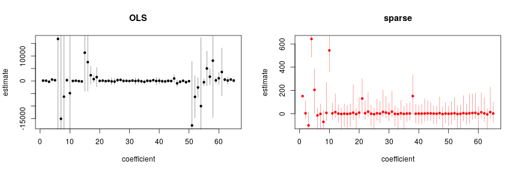

The coefficient estimates from OLS are *wierd*.

```
##                      ols           stan
## (Intercept)    150.40351  150.441968698
## `tc:ldl`    -17718.75773    0.033353836
## tc           16796.16643  -15.094758817
## ldl         -15061.25410   -2.803126530
## `tc^2`       11301.51242   -0.566494009
## `tc:ltg`    -10009.29895   -1.458708736
## `ldl:ltg`     8124.59404    5.071689135
## `ldl^2`       7536.39662   -2.487378411
## `tc:hdl`     -6298.38254    2.990296176
## hdl          -6254.46319  -70.904720898
## `ldl:hdl`     5004.48290    0.156320821
## ltg          -4856.91364  544.081396337
## `hdl:ltg`     3597.25613   11.198654641
## `tc:tch`     -2574.37368   -3.182541198
## `hdl^2`       2298.16669   -0.298001012
## `ldl:tch`     1731.89234    2.660811733
## `ltg^2`       1549.77906   -4.036317748
## `hdl:tch`     1076.35481   -2.417174388
## `map:tc`      1003.12227   -0.048598374
## `map:ldl`     -916.96996   -0.694345338
## `tch^2`        756.03682    8.022192132
## `tch:glu`      596.19136   12.736974731
## bmi            587.85483  643.162520011
## `hdl:glu`      560.73667    2.215087063
## `tc:glu`      -497.85900    3.832447892
## `map:ltg`     -455.17300    0.520230473
## `age:tch`      450.27383   -0.007549981
## `age:hdl`      349.10626    2.512926502
## tch            330.71500    6.514453051
## `bmi:map`      326.31803  151.029322377
## map            323.09057  204.692791124
## `sex:tch`     -314.48509   -2.378188538
## `map:hdl`     -303.16364    3.691671900
## sex           -286.08810 -101.765851787
## `ldl:glu`      265.99329    7.018465292
## `age:ldl`     -215.12650   -4.823499031
## `tch:ltg`      212.46622   -6.586308746
## `ltg:glu`      172.80190    0.812160488
## `sex:map`      165.15332   16.293653062
```

[output cut: 11 more lines]

```
## `map:tch`       83.43006   -4.218316446
## `age:map`       73.42593   16.507539257
## `bmi:ltg`       70.84372    2.259593599
## `map:glu`      -65.99667   -1.318668568
## `age:glu`       65.26740    8.438687365
## `bmi^2`        -57.66550    0.095112982
## `age:bmi`      -51.02631    3.575305840
## `glu^2`         49.71817    8.064464238
## `age:ltg`       31.70304   14.258226696
## `sex:glu`       24.91435    1.137130088
## `bmi:tc`        21.50722   -0.665490953
## glu             19.12792    2.300361215
## `sex:tc`       -15.98984   -1.999827883
## `sex:bmi`      -14.04317    0.938191184
## `bmi:glu`       11.21618    1.642182837
```

And, quite different than what Stan gets.

```
##                      ols           stan
## (Intercept)    150.40351  150.441968698
## bmi            587.85483  643.162520011
## ltg          -4856.91364  544.081396337
## map            323.09057  204.692791124
## `bmi:map`      326.31803  151.029322377
## `age:sex`      149.66531  129.941006661
## sex           -286.08810 -101.765851787
## hdl          -6254.46319  -70.904720898
## `age:map`       73.42593   16.507539257
## `sex:map`      165.15332   16.293653062
## tc           16796.16643  -15.094758817
## `age:ltg`       31.70304   14.258226696
## `tch:glu`      596.19136   12.736974731
## `age^2`        123.34475   12.703843426
## `hdl:ltg`     3597.25613   11.198654641
## `age:glu`       65.26740    8.438687365
## `glu^2`         49.71817    8.064464238
## `tch^2`        756.03682    8.022192132
## `ldl:glu`      265.99329    7.018465292
## `tch:ltg`      212.46622   -6.586308746
## tch            330.71500    6.514453051
## `ldl:ltg`     8124.59404    5.071689135
## `age:ldl`     -215.12650   -4.823499031
## `map:tch`       83.43006   -4.218316446
## `ltg^2`       1549.77906   -4.036317748
## `tc:glu`      -497.85900    3.832447892
## `sex:ldl`      125.00529   -3.746752079
## `map:hdl`     -303.16364    3.691671900
## `age:bmi`      -51.02631    3.575305840
## `map^2`       -161.86028   -3.306257826
## `tc:tch`     -2574.37368   -3.182541198
## `tc:hdl`     -6298.38254    2.990296176
## `sex:hdl`     -108.67040    2.856477713
## ldl         -15061.25410   -2.803126530
## age            131.03118    2.742276426
## `ldl:tch`     1731.89234    2.660811733
## `age:hdl`      349.10626    2.512926502
## `ldl^2`       7536.39662   -2.487378411
## `hdl:tch`     1076.35481   -2.417174388
```

[output cut: 11 more lines]

```
## `ltg:glu`      172.80190    0.812160488
## `age:tc`      -147.14797   -0.731836716
## `map:ldl`     -916.96996   -0.694345338
## `bmi:tc`        21.50722   -0.665490953
## `tc^2`       11301.51242   -0.566494009
## `map:ltg`     -455.17300    0.520230473
## `bmi:ldl`       92.41196   -0.366628908
## `hdl^2`       2298.16669   -0.298001012
## `sex:ltg`       97.47348    0.239873862
## `bmi:hdl`     -101.63216   -0.230827419
## `ldl:hdl`     5004.48290    0.156320821
## `bmi^2`        -57.66550    0.095112982
## `map:tc`      1003.12227   -0.048598374
## `tc:ldl`    -17718.75773    0.033353836
## `age:tch`      450.27383   -0.007549981
```

Now let’s look at out-of-sample prediction error, using the posterior median coefficient estimates:

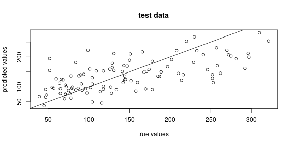

```r
pred_stan <- function (x) {
    post_med_intercept + as.matrix(x) %*% post_med_slopes
}
pred_y <- pred_stan(test_d[,-1])
stan_pred_error <- sqrt(mean((test_d$y - pred_y)^2))
stan_mse_resid <- sqrt(mean((training_d$y - pred_stan(training_d[,-1]))^2))

plot(test_d$y, pred_y, xlab="true values", ylab="predicted values", main="test data")
abline(0,1)
```

## Conclusions?

1. Our “sparse” model is certainly more sparse, and arguably more interpretable.
2. It has a root-mean-square prediction error of 55.7274879 on the *test* data, and 52.083831 on the training data.
3. This is substantially better than ordinary linear regression, which had a root-mean-square prediction error of 64.602275 on the test data, and a root-mean-square-error of 46.5588313 on the training data.

The sparse model is more interpretable, and more generalizable.